# Data Science Project for Opal card usage in transportation of NSW

This Data Science project shows the detail of travels like number and time of tap on/off for different mode of transportation in NSW. Represent these details on daily and monthly basis for clear view of the route used. Prediction of busiest and emptiest route for different mode of transportation specially buses and trains. It illustrates number of tap on/off based on location and time. It also represents opal card usage on the basis of age group. Graphical representation of all detail make it easy to understand

```python
# loading libraries
import pandas as pd
import numpy as np
import geoviews as gv
import geoviews.tile_sources as gvts
from geoviews import dim, opts
%pylab inline
rcParams['figure.figsize'] = 10,9
gv.extension('bokeh')

# Using Bokeh libraries
from bokeh.plotting import figure, output_file, show
from bokeh.models import ColumnDataSource
from bokeh.models.tools import HoverTool
from bokeh.palettes import Spectral5
from bokeh.transform import factor_cmap

#Loading libraries
from sklearn import preprocessing
import matplotlib.pyplot as plt
plt.rc("font", size=14)
from sklearn.linear_model import LogisticRegression
from sklearn.model_selection import train_test_split
import seaborn as sns
sns.set(style="white")
sns.set(style="whitegrid", color_codes=True)
from sklearn import linear_model
from sklearn.metrics import r2_score
from sklearn.feature_extraction.text import CountVectorizer,TfidfVectorizer
```

## Number of tap-on and tap-off based on location on both daily and monthly basis using visualization techniques

To read in the data, we imported the pandas package and read in the CSV of Opal tap-on/off location. We can use the read_csv() function to do this:

```python
TapOnoffData_11_2016 = pd.read_csv('Data/Tap-on-off/Tapon_off_time_loc_20161121-27.csv')
TapOnoffData_12_2016 = pd.read_csv('Data/Tap-on-off/Tapon_off_time_loc_20161226-20170101.csv')
TapOnoffData_07_2016 = pd.read_csv('Data/Tap-on-off/Tapon_Tapoff_time-loc_20160725-31.csv')
TapOnoffData_08_2016 = pd.read_csv('Data/Tap-on-off/tapon_tapoff_time-loc_20160808-14.csv')

# Merging in a data frame
frames = [TapOnoffData_11_2016, TapOnoffData_12_2016,TapOnoffData_07_2016,TapOnoffData_08_2016]

TapOnoffDataMerge = pd.concat(frames, sort=False)

# Remove NaN vales
TapOnoffDataMerge = TapOnoffDataMerge.dropna()
TapOnoffDataMerge.head()
```

|  | mode | date | tap | time | loc | count |
| --- | --- | --- | --- | --- | --- | --- |
| 0 | bus | 20161121 | off | 0:00 | 2000 | 82.0 |
| 1 | bus | 20161121 | off | 0:00 | 2022 | 19.0 |
| 2 | bus | 20161121 | off | 0:00 | 2026 | 28.0 |
| 3 | bus | 20161121 | off | 0:00 | 2050 | 27.0 |
| 4 | bus | 20161121 | off | 0:15 | 2000 | 62.0 |

**VARIABLE DESCRIPTIONS:**

1. Mode is the transportation mode.
2. Date is in format YYYYMMDD.
3. Tap is the tap type- either on or off indicating departure (on) or arrival (off).
4. Binned time is 24 hour format. Time is binned to 15 minutes interval.
5. loc is location. 4 digit no indicate Postcode.
6. Count is the number of tap occurance.

### Q1. What are the most popular stations overall (and least Popular)?

1. In order to find out the most popular station, we will be using groupby to find total occurance of tap on a location basis.

```python
dt = TapOnoffDataMerge[TapOnoffDataMerge['mode'] == 'train']
Station_Group = dt.groupby('loc')['count'].sum().to_frame()
Station_Group

Station_Totals = pd.DataFrame(dt.groupby('loc')['count'].sum().to_frame())

# setting ascending equals false to generate highest number of occurance
Station_Totals.sort_values(ascending=False,by='count',inplace=True)
Station_Totals = Station_Totals.reset_index()
Station_Totals.head()
```

|  | loc | count |
| --- | --- | --- |
| 0 | Town Hall Station | 4886157.0 |
| 1 | Central Station | 4648673.0 |
| 2 | Wynyard Station | 2918578.0 |
| 3 | Parramatta Station | 1490167.0 |
| 4 | Circular Quay Station | 1483255.0 |

### Top 5 most Popular Stations

```python
from bokeh.models import ColumnDataSource, NumeralTickFormatter, HoverTool

Top10_Station_Totals = Station_Totals.head(5)

source = ColumnDataSource(Top10_Station_Totals)
countries = source.data['loc'].tolist()
p = figure(x_range=countries)


color_map = factor_cmap(field_name='loc',
                    palette=Spectral5, factors=countries)

p.vbar(x='loc', top='count', source=source, width=0.70, color=color_map)
p.yaxis[0].formatter = NumeralTickFormatter(format='00')
p.title.text ='Top 5 Most Popular Station'
p.xaxis.axis_label = 'Stations'
p.yaxis.axis_label = 'Total Passenger'

hover = HoverTool()
hover.tooltips = [
    ('Location', '@loc'),
            ('Passenger', '@count')]

hover.mode = 'vline'

p.add_tools(hover)
```

```python
# Style function that takes in a plot
def style(p):
    # Title
    p.title.align = 'center'
    p.title.text_font_size = '20pt'
    p.title.text_font = 'serif'

    # Axis titles
    p.xaxis.axis_label_text_font_size = '14pt'
    p.xaxis.axis_label_text_font_style = 'bold'
    p.yaxis.axis_label_text_font_size = '14pt'
    p.yaxis.axis_label_text_font_style = 'bold'

    # Tick labels
    p.xaxis.major_label_text_font_size = '8pt'
    p.yaxis.major_label_text_font_size = '12pt'

    return p


styled_p = style(p)

# Show plot
show(styled_p)
```

[interactive chart not shown]

```python
Top5_Station_Totals = Station_Totals.tail(5)

source = ColumnDataSource(Top5_Station_Totals)
countries = source.data['loc'].tolist()
p = figure(x_range=countries)


color_map = factor_cmap(field_name='loc',
                    palette=Spectral5, factors=countries)

p.vbar(x='loc', top='count', source=source, width=0.70, color=color_map)
p.yaxis[0].formatter = NumeralTickFormatter(format='00')
p.title.text ='Top 5 least popular station'
p.xaxis.axis_label = 'Stations'
p.yaxis.axis_label = 'Total Passenger'

hover = HoverTool()
hover.tooltips = [
    ('Location', '@loc'),
            ('Passenger', '@count')]

hover.mode = 'vline'

p.add_tools(hover)
```

```python
# Add Aesthetics
styled_p = style(p)

# Show plot
show(styled_p)
```

[interactive chart not shown]

### **Answer:-** Here, we can see that 'Town Hall' seems to be the most busiest and 'Medlow Bath' seems to be the least busiest station based on the number of occurance.

### Q2) Which route is busiest or emptest based on Bus service?

### Data Cleaning and Aggregation

1. Coverting date field to standard format and aggregating it to monthly basis so that we can identify which route is busiest and emptest.

```python
# Parsing date to standard format
TapOnoffDataMerge['Parsed date'] = pd.to_datetime(TapOnoffDataMerge['date'], format="%Y%m%d")
TapOnoffDataMerge1 =  TapOnoffDataMerge.dropna()
TapOnoffDataMergeFinal = TapOnoffDataMerge1[TapOnoffDataMerge1['mode'] == 'bus']

# Aggregating on monthly basis
dt = TapOnoffDataMergeFinal.groupby(['loc','tap',pd.Grouper(key='Parsed date', freq='M')])['count'].sum().reset_index().sort_values('count')
dt.head()
```

|  | loc | tap | Parsed date | count |
| --- | --- | --- | --- | --- |
| 2079 | 2752 | off | 2016-07-31 | 18.0 |
| 1213 | 2197 | on | 2016-12-31 | 18.0 |
| 2197 | 2775 | on | 2016-07-31 | 18.0 |
| 1133 | 2174 | on | 2016-07-31 | 18.0 |
| 1730 | 2306 | on | 2016-12-31 | 18.0 |

### Here, loc is a 4 digit Postcode. We need to find a lookup to these code.The postal Code has been downloaded from Link:- [Postal Code](https://www.matthewproctor.com/australian_postcodes)

```python
# Downloading Post code dump and importing
pd.set_option('mode.chained_assignment', None)
AusPostalCode = pd.read_csv('Data/Tap-on-off/australian_postcodes.csv')
AusPostalCodeNSW = AusPostalCode[AusPostalCode['state'] == 'NSW']
AusPostalCodeNSW1 = AusPostalCodeNSW.dropna()
AusPostalCodeNSW1['Post code'] = AusPostalCodeNSW1['postcode'].apply(str)
AusPostalCodeNSW1.head()
```

|  | id | postcode | locality | state | long | lat | dc | type | status | sa3 | sa3name | sa4 | sa4name | region | Post code |
| --- | --- | --- | --- | --- | --- | --- | --- | --- | --- | --- | --- | --- | --- | --- | --- |
| 420 | 458 | 1001 | SYDNEY | NSW | 151.268071 | -33.794883 | EAST SUBS MC | LVR | Updated 25-Mar-2020 SA3 | 11703.0 | Sydney Inner City | 117.0 | Sydney - City and Inner South | R1 | 1001 |
| 421 | 459 | 1002 | SYDNEY | NSW | 151.268071 | -33.794883 | EAST SUBS MC | LVR | Updated 25-Mar-2020 SA3 | 11703.0 | Sydney Inner City | 117.0 | Sydney - City and Inner South | R1 | 1002 |
| 422 | 460 | 1003 | SYDNEY | NSW | 151.268071 | -33.794883 | EAST SUBS MC | LVR | Updated 25-Mar-2020 SA3 | 11703.0 | Sydney Inner City | 117.0 | Sydney - City and Inner South | R1 | 1003 |
| 423 | 461 | 1004 | SYDNEY | NSW | 151.268071 | -33.794883 | EAST SUBS MC | LVR | Updated 25-Mar-2020 SA3 | 11703.0 | Sydney Inner City | 117.0 | Sydney - City and Inner South | R1 | 1004 |
| 424 | 462 | 1005 | SYDNEY | NSW | 151.268071 | -33.794883 | GPO BOX CENTRE | LVR | Updated 25-Mar-2020 SA3 | 11703.0 | Sydney Inner City | 117.0 | Sydney - City and Inner South | R1 | 1005 |

```python
# Merging Post code to get longitude and latitude
AusPostalCodeNSWFinal = pd.merge(AusPostalCodeNSW1, dt, how='inner', left_on='Post code', right_on='loc')
AusPostalCodeNSWFinal.head()
```

|  | id | postcode | locality | state | long | lat | dc | type | status | sa3 | sa3name | sa4 | sa4name | region | Post code | loc | tap | Parsed date | count |
| --- | --- | --- | --- | --- | --- | --- | --- | --- | --- | --- | --- | --- | --- | --- | --- | --- | --- | --- | --- |
| 0 | 20208 | 2000 | BARANGAROO | NSW | 151.20158 | -33.86052 | Sydney Metro | Delivery Area | Updated 6-Feb-2020 | 11703.0 | Sydney Inner City | 117.0 | Sydney - City and Inner South | R1 | 2000 | 2000 | off | 2016-12-31 | 418337.0 |
| 1 | 20208 | 2000 | BARANGAROO | NSW | 151.20158 | -33.86052 | Sydney Metro | Delivery Area | Updated 6-Feb-2020 | 11703.0 | Sydney Inner City | 117.0 | Sydney - City and Inner South | R1 | 2000 | 2000 | on | 2016-12-31 | 419403.0 |
| 2 | 20208 | 2000 | BARANGAROO | NSW | 151.20158 | -33.86052 | Sydney Metro | Delivery Area | Updated 6-Feb-2020 | 11703.0 | Sydney Inner City | 117.0 | Sydney - City and Inner South | R1 | 2000 | 2000 | off | 2016-07-31 | 800139.0 |
| 3 | 20208 | 2000 | BARANGAROO | NSW | 151.20158 | -33.86052 | Sydney Metro | Delivery Area | Updated 6-Feb-2020 | 11703.0 | Sydney Inner City | 117.0 | Sydney - City and Inner South | R1 | 2000 | 2000 | off | 2016-11-30 | 800651.0 |
| 4 | 20208 | 2000 | BARANGAROO | NSW | 151.20158 | -33.86052 | Sydney Metro | Delivery Area | Updated 6-Feb-2020 | 11703.0 | Sydney Inner City | 117.0 | Sydney - City and Inner South | R1 | 2000 | 2000 | on | 2016-07-31 | 812235.0 |

```python
AusPostalCodeNSWState = AusPostalCodeNSWFinal[AusPostalCodeNSWFinal['state'] == 'NSW']

# Selecting specific fields
dt1 = AusPostalCodeNSWState.groupby(['long','lat','tap','sa4name','Parsed date'])[['count']].sum().reset_index().sort_values('count')
dt1['Date'] = dt['Parsed date'].apply(str)
dt2 = dt1.dropna()
dt2.columns = ['longitude','latitude','tap','SubUrb','Date','TotalPassenger','Origdate']
dt2['Date'] = dt2['Date'].apply(str)
dt2.head()
```

|  | longitude | latitude | tap | SubUrb | Date | TotalPassenger | Origdate |
| --- | --- | --- | --- | --- | --- | --- | --- |
| 19 | 150.431839 | -33.725566 | off | Sydney - Outer West and Blue Mountains | 2016-11-30 00:00:00 | 18.0 | 2016-12-31 00:00:00 |
| 2186 | 151.281538 | -33.624340 | on | Sydney - Northern Beaches | 2016-11-30 00:00:00 | 18.0 | 2016-08-31 00:00:00 |
| 978 | 151.038741 | -33.311450 | on | Sydney - Baulkham Hills and Hawkesbury | 2016-07-31 00:00:00 | 18.0 | 2016-07-31 00:00:00 |
| 837 | 150.998155 | -33.901198 | on | Sydney - Parramatta | 2016-12-31 00:00:00 | 18.0 | 2016-11-30 00:00:00 |
| 13 | 150.366015 | -33.704416 | off | Sydney - Outer West and Blue Mountains | 2016-12-31 00:00:00 | 18.0 | 2016-08-31 00:00:00 |

```python
dt2['City'] = 'Sydney'
tapOn_gv_points = gv.Points(dt2, ['longitude', 'latitude'],
                               ['tap', 'SubUrb', 'Date',
                               'TotalPassenger','City'])
```

```python
from bokeh.models import HoverTool

tooltips = [
            ('Total Passenger', '@TotalPassenger'),
            ('tap', '@tap'),
            ('SubUrb', '@SubUrb'),
            ("Date", "@Date"),
            ]



hover = HoverTool(tooltips = tooltips)

TapONOFF = (gvts.Wikipedia * tapOn_gv_points).opts(
    opts.Points(width=1000, height=700, alpha=0.3,
                xaxis=None, yaxis=None,hover_line_color='red',
                line_color="Black",
                title="For Buses using Tap On/off",
                 fill_color="#FF0000",fill_alpha=0.05,
                tools=[hover],hover_fill_color=None, hover_fill_alpha=0.5,
                size=np.sqrt(np.sqrt(dim('TotalPassenger')))))

TapONOFF
```

[interactive chart not shown]

### **Answer:-** "Sydney-City and inner South" suburb seems to be the busiest suburb and 'Sydney Outer west and Blue Mountains' seems to be the emptest suburb when we see bus service. Now, we will add interactive widgets where we can filter based on date, tap, and suburb and look for total passenger details.

```python
from bokeh.models import HoverTool

tooltips = [
            ('Passenger', '@TotalPassenger'),
            ('tap', '@tap'),
            ('SubUrb', '@SubUrb'),
            ("Date", "@Date"),
            ]

hover = HoverTool(tooltips = tooltips)

points_grouped = gv.Points(dt2, kdims=['longitude', 'latitude'], vdims=['Date','tap','SubUrb','TotalPassenger'])\
                   .groupby(['Date','tap','SubUrb'])
plot_grouped = (gvts.Wikipedia) * points_grouped.opts(opts.Points(width=1000, height=700, alpha=0.3,
                xaxis=None, yaxis=None,hover_line_color='black',
                line_color="Black",
                 fill_color="#FF0000",
                tools=[hover],hover_fill_color=None, hover_fill_alpha=0.5,
                size=np.sqrt(dim('TotalPassenger'))))
plot_grouped.opts(width=500, height=400)
```

[interactive chart not shown]

### Here, we can apply filter and look for taps on/off based on the particular location.

### **Q3.Which is the peak hour where we see the most trafic congession on the station?**

```python
# creating a function that extract hours from time
def Convert_to_hours(time):
        j = time[:2]
        k = j.replace(':','')
        return k
```

### Missing Value:-

```python
TapOnoffDataMerge['hours'] = TapOnoffDataMerge['time'].apply(Convert_to_hours)
TapOnoffDataTrain = TapOnoffDataMerge[TapOnoffDataMerge['mode'] == 'train']
TapOnoffDataTrain
TapOnoffGroupTrain = TapOnoffDataTrain.groupby(['tap','loc','hours'])['count'].sum().to_frame()
TapOnoffGroupTrainMerge = TapOnoffGroupTrain.reset_index()

filterhours = TapOnoffGroupTrainMerge.loc[~TapOnoffGroupTrainMerge['hours'].isin(['-1','0'])]
set(filterhours['hours'].apply(int))

arr_hist, edges = np.histogram(filterhours['hours'].apply(int),
                               bins = 20,
                               range = [1, 24])

Taps = pd.DataFrame({'Total Taps': arr_hist,
                       'left': edges[:-1],
                       'right': edges[1:]})
```

```python
#from bokeh.plotting import figure
#from bokeh.io import show, output_notebook

p = figure(plot_height = 600, plot_width = 600,
           title = 'Histogram of train Tap On/Off',
          x_axis_label = 'Hours',
           y_axis_label = 'Number of Passenger')

# Add a quad glyph
p.quad(bottom=0, top=arr_hist, left=edges[:-1], right=edges[1:], fill_color='red', line_color='black')



styled_p = style(p)

# Show plot
show(styled_p)
```

[interactive chart not shown]

```python
from bokeh.models import ColumnDataSource
```

```python
# Formatted columns for Hover Tooltips (see next section)
Taps['Taponoff'] = ['%d taps' % count for count in Taps['Total Taps']]
Taps['Tinterval'] = ['%d to %d hours' % (left, right) for left, right in zip(Taps['left'], Taps['right'])]

Taps.head()
```

|  | Total Taps | left | right | Taponoff | Tinterval |
| --- | --- | --- | --- | --- | --- |
| 0 | 131 | 1.00 | 2.15 | 131 taps | 1 to 2 hours |
| 1 | 6 | 2.15 | 3.30 | 6 taps | 2 to 3 hours |
| 2 | 109 | 3.30 | 4.45 | 109 taps | 3 to 4 hours |
| 3 | 250 | 4.45 | 5.60 | 250 taps | 4 to 5 hours |
| 4 | 359 | 5.60 | 6.75 | 359 taps | 5 to 6 hours |

```python
# Convert to column data source
src = ColumnDataSource(Taps)
src.data.keys()
```

```
dict_keys(['index', 'Total Taps', 'left', 'right', 'Taponoff', 'Tinterval'])
```

```python
# Import the hover tool class
from bokeh.models import HoverTool
```

```python
# Create the blank plot
p = figure(plot_height = 600, plot_width = 600,
           title = 'Histogram of train on hourly basis',
          x_axis_label = 'Hours',
           y_axis_label = 'Total Passenger')

# Add a quad glyph with source this time
p.quad(bottom=0, top='Total Taps', left='left', right='right', source=src,
       fill_color='red', line_color='black', fill_alpha = 0.75,
       hover_fill_alpha = 1.0, hover_fill_color = 'navy')

# Add a hover tool referring to the formatted columns
hover = HoverTool(tooltips = [('Hours', '@Tinterval'),
                             ('Total Passenger', '@Taponoff')])

# Style the plot
p = style(p)

# Add the hover tool to the graph
p.add_tools(hover)

# Show the plot
show(p)
```

[interactive chart not shown]

### **Ans:-** The peak time for traffic congession on the station is from 7 to 9 am and from 15 to 17 PM. The least traffic congession seems to be from 2 to 3 am.

## To depict the relationship between the age group of travellers and their respective location using various techniques and demonstrating the results properly in figures and plots.

Initially, we will read the dataset followed by the data exploration. After cleaning and decorating the data, we will group and aggregate the data using various techniques. The overall result of the implementation of dataset is properly illustrated in the graphs at last.

The queries that will be addressed in this part of analysis are:

#### 1) Which age group travel the most and least using train card in overall?

#### 2) Based on the specific location, which age group has the most and least of travelling in accordance to it?

### Reading the dataset

The data file that we have used here is csv type and an encoder is used here to decode the file.

```python
#Reading the csv file
data = pd.read_csv('Data/Train/train_card_type.csv', encoding='utf8')
data.head()
```

|  | Location | Type | 16-Jul | 16-Aug | 16-Sep | 16-Oct | 16-Nov | 16-Dec | 17-Jan | 17-Feb | ... | 19-Jun | 19-Jul | 19-Aug | 19-Sep | 19-Oct | 19-Nov | 19-Dec | 20-Jan | 20-Feb | 20-Mar |
| --- | --- | --- | --- | --- | --- | --- | --- | --- | --- | --- | --- | --- | --- | --- | --- | --- | --- | --- | --- | --- | --- |
| 0 | T1 North Shore, Northern and Western Line | Adult | 8,575,135 | 9,484,134 | 8,956,112 | 8,778,524 | 9,221,978 | 8,036,202 | 7,774,754 | 8,446,672 | ... | NaN | NaN | NaN | NaN | NaN | NaN | NaN | NaN | NaN | NaN |
| 1 | T1 North Shore, Northern and Western Line | Child/Youth | 432,083 | 370,300 | 425,154 | 438,430 | 404,288 | 505,401 | 552,039 | 394,228 | ... | NaN | NaN | NaN | NaN | NaN | NaN | NaN | NaN | NaN | NaN |
| 2 | T1 North Shore, Northern and Western Line | Concession | 790,206 | 1,081,373 | 855,554 | 839,434 | 677,907 | 524,749 | 488,489 | 607,040 | ... | NaN | NaN | NaN | NaN | NaN | NaN | NaN | NaN | NaN | NaN |
| 3 | T1 North Shore, Northern and Western Line | Day Pass Child/Youth w/o SAF | NaN | NaN | NaN | NaN | NaN | NaN | NaN | NaN | ... | NaN | NaN | NaN | NaN | NaN | NaN | NaN | NaN | NaN | NaN |
| 4 | T1 North Shore, Northern and Western Line | Day Pass without SAF | NaN | NaN | NaN | NaN | NaN | NaN | NaN | NaN | ... | NaN | NaN | NaN | NaN | NaN | NaN | NaN | NaN | NaN | NaN |

5 rows × 47 columns

The csv file consists of so many NaN values, so we have to remove those values in order to decorate the data.

```python
# Removing NaN vales
new_data = data.dropna()
new_data
```

|  | Location | Type | 16-Jul | 16-Aug | 16-Sep | 16-Oct | 16-Nov | 16-Dec | 17-Jan | 17-Feb | ... | 19-Jun | 19-Jul | 19-Aug | 19-Sep | 19-Oct | 19-Nov | 19-Dec | 20-Jan | 20-Feb | 20-Mar |
| --- | --- | --- | --- | --- | --- | --- | --- | --- | --- | --- | --- | --- | --- | --- | --- | --- | --- | --- | --- | --- | --- |
| 22 | T3 Bankstown Line | Adult | 1,615,473 | 1,767,064 | 1,689,548 | 1,691,384 | 1,747,282 | 1,588,061 | 1,529,871 | 1,557,785 | ... | 1,801,128 | 1,768,502 | 1,690,069 | 1,671,643 | 1,875,578 | 1,729,551 | 1,517,584 | 1,497,515 | 1,471,542 | 1,129,617 |
| 23 | T3 Bankstown Line | Child/Youth | 83,619 | 76,553 | 86,852 | 91,282 | 81,801 | 103,801 | 112,245 | 75,895 | ... | 87,510 | 99,658 | 70,964 | 73,410 | 101,014 | 77,779 | 93,555 | 99,423 | 68,349 | 40,950 |
| 24 | T3 Bankstown Line | Concession | 174,271 | 215,917 | 174,931 | 168,905 | 139,608 | 111,584 | 104,421 | 121,362 | ... | 153,395 | 142,319 | 172,549 | 152,453 | 175,235 | 143,232 | 107,187 | 98,280 | 129,335 | 120,352 |
| 28 | T3 Bankstown Line | Employee | 13,196 | 15,391 | 15,547 | 15,093 | 16,371 | 15,432 | 13,597 | 14,636 | ... | 17,837 | 17,013 | 15,991 | 16,403 | 18,802 | 17,792 | 16,324 | 15,967 | 16,100 | 14,277 |
| 29 | T3 Bankstown Line | Free Travel | 1,087 | 1,328 | 1,338 | 1,361 | 1,545 | 1,396 | 1,221 | 1,360 | ... | 1,881 | 1,803 | 1,643 | 1,692 | 1,979 | 1,795 | 1,628 | 1,415 | 1,466 | 1,082 |
| ... | ... | ... | ... | ... | ... | ... | ... | ... | ... | ... | ... | ... | ... | ... | ... | ... | ... | ... | ... | ... | ... |
| 137 | Southern Highlands Line | School Student | 776 | 1,960 | 1,499 | 1,331 | 1,731 | 643 | 110 | 1,778 | ... | 2,382 | 1,464 | 2,764 | 2,574 | 1,855 | 2,640 | 1,293 | 265 | 2,497 | 1,869 |
| 138 | Southern Highlands Line | Senior/Pensioner | 16,183 | 17,403 | 20,921 | 18,993 | 19,116 | 17,819 | 16,653 | 17,165 | ... | 18,100 | 19,139 | 19,149 | 20,287 | 24,010 | 19,694 | 15,987 | 14,479 | 16,593 | 11,106 |
| 139 | Southern Highlands Line | Sgl Trip Rail Adult | 89 | 606 | 581 | 612 | 581 | 633 | 634 | 482 | ... | 332 | 352 | 316 | 292 | 348 | 294 | 302 | 228 | 245 | 182 |
| 140 | Southern Highlands Line | Sgl Trip Rail Child/Youth | 41 | 121 | 236 | 179 | 116 | 268 | 275 | 93 | ... | 116 | 228 | 136 | 118 | 169 | 93 | 144 | 138 | 71 | 63 |
| 245 | Grand Total | Total | 28,819,249 | 32,393,980 | 30,648,352 | 30,106,833 | 31,318,279 | 28,189,584 | 26,735,422 | 28,767,036 | ... | 32,112,300 | 34,148,122 | 34,927,511 | 33,518,338 | 34,998,484 | 34,137,150 | 30,275,150 | 29,399,461 | 30,168,810 | 22,510,087 |

82 rows × 47 columns

Digging into this data, the variables here are:

Location provides the position or area of train card usage.

Type consists of various kind of Train cards such as Adult, Child/Youth, Employee and Free Travel etc.

Similarly, the usage of train card type are based on different date as per the data.

The type column of the dataset has many categories and we need to reduce the categories for a better modelling. The type column has the following categories:

## Exploring the data

```python
new_data['Type'].unique()
```

```
array(['Adult', 'Child/Youth', 'Concession', 'Employee', 'Free Travel',
       'School Student', 'Senior/Pensioner', 'Sgl Trip Rail Adult',
       'Sgl Trip Rail Child/Youth', 'Total'], dtype=object)
```

```python
data['Location'].value_counts()
```

```
T1 Northern Line                             12
T6 Carlingford Line                          12
T1 North Shore Line                          12
T3 Bankstown Line                            12
T5 Cumberland Line                           12
T8 Airport and South Line                    12
T9 Northern Line                             12
Central Coast Newcastle Line                 12
Blue Mountains Line                          12
Hunter Line                                  12
T7 Olympic Park Line                         12
South Coast Line                             12
T2 Inner West Line                           12
T1 Western Line                              12
T2 Leppington Line                           12
T4 Eastern Suburbs and Illawarra Line        12
Station Link                                 11
Southern Highlands Line                      11
T1 North Shore, Northern and Western Line    11
T2 Airport, Inner West and South Line        11
T6 replacement buses                          9
Grand Total                                   1
Name: Location, dtype: int64
```

```python
new_data['Type'].value_counts()
```

```
Employee                     9
Senior/Pensioner             9
Free Travel                  9
Child/Youth                  9
Sgl Trip Rail Child/Youth    9
Concession                   9
Sgl Trip Rail Adult          9
Adult                        9
School Student               9
Total                        1
Name: Type, dtype: int64
```

```python
# Examining the data
new_data.info()
```

```
<class 'pandas.core.frame.DataFrame'>
Int64Index: 82 entries, 22 to 245
Data columns (total 47 columns):
Location    82 non-null object
Type        82 non-null object
16-Jul      82 non-null object
16-Aug      82 non-null object
16-Sep      82 non-null object
16-Oct      82 non-null object
16-Nov      82 non-null object
16-Dec      82 non-null object
17-Jan      82 non-null object
17-Feb      82 non-null object
17-Mar      82 non-null object
17-Apr      82 non-null object
17-May      82 non-null object
17-Jun      82 non-null object
17-Jul      82 non-null object
17-Aug      82 non-null object
17-Sep      82 non-null object
17-Oct      82 non-null object
17-Nov      82 non-null object
17-Dec      82 non-null object
18-Jan      82 non-null object
18-Feb      82 non-null object
18-Mar      82 non-null object
18-Apr      82 non-null object
18-May      82 non-null object
18-Jun      82 non-null object
18-Jul      82 non-null object
18-Aug      82 non-null object
18-Sep      82 non-null object
18-Oct      82 non-null object
18-Nov      82 non-null object
18-Dec      82 non-null object
19-Jan      82 non-null object
19-Feb      82 non-null object
19-Mar      82 non-null object
19-Apr      82 non-null object
19-May      82 non-null object
19-Jun      82 non-null object
19-Jul      82 non-null object
19-Aug      82 non-null object
19-Sep      82 non-null object
19-Oct      82 non-null object
19-Nov      82 non-null object
19-Dec      82 non-null object
20-Jan      82 non-null object
20-Feb      82 non-null object
20-Mar      82 non-null object
dtypes: object(47)
memory usage: 30.8+ KB
```

```python
#looking at the statistical summary
new_data.describe()
```

|  | Location | Type | 16-Jul | 16-Aug | 16-Sep | 16-Oct | 16-Nov | 16-Dec | 17-Jan | 17-Feb | ... | 19-Jun | 19-Jul | 19-Aug | 19-Sep | 19-Oct | 19-Nov | 19-Dec | 20-Jan | 20-Feb | 20-Mar |
| --- | --- | --- | --- | --- | --- | --- | --- | --- | --- | --- | --- | --- | --- | --- | --- | --- | --- | --- | --- | --- | --- |
| count | 82 | 82 | 82 | 82 | 82 | 82 | 82 | 82 | 82 | 82 | ... | 82 | 82 | 82 | 82 | 82 | 82 | 82 | 82 | 82 | 82 |
| unique | 10 | 10 | 82 | 81 | 81 | 82 | 81 | 82 | 81 | 82 | ... | 82 | 82 | 81 | 82 | 81 | 82 | 82 | 82 | 82 | 82 |
| top | Blue Mountains Line | Employee | 2,525 | 570 | 581 | 86 | 220 | 43 | 360 | 43 | ... | 4,373 | 830 | 1,009 | 235,031 | 208 | 43 | 184 | 8,952 | 76,872 | 11,811 |
| freq | 9 | 9 | 1 | 2 | 2 | 1 | 2 | 1 | 2 | 1 | ... | 1 | 1 | 2 | 1 | 2 | 1 | 1 | 1 | 1 | 1 |

4 rows × 47 columns

### Data grouping

Similarly, also merge “Sgl Trip Rail Adult" into " Adult".

Likewise, let's put all the card types such as 'Free Travel', 'Concession', 'Day Pass without SAF' and 'CTP' into the same group named as 'Privileged'.

Since, we need a new column for the grouped data, we assigned the grouped data from Type column into a new column Card Type.

```python
#Grouping and aggregating the data
def func(row):
    if row['Adult'] == 'Adult':
        return 'Adult'
    elif row['Child/Youth'] == 'Child/Youth':
        return 'Child/Youth'
    elif row['Employee'] == 'Employee':
        return 'Employee'
    elif row['Sgl Trip Rail Adult'] == 'Sgl Trip Rail Adult':
        return 'Adult'
    elif row['School Student'] == 'School Student':
        return 'School Student'
    elif row['Senior/Pensioner'] == 'Senior/Pensioner':
        return 'Senior/Pensioner'
    elif row['Free Travel'] == 'Free Travel':
        return 'Privileged'
    elif row['Concession'] == 'Concession':
        return 'Privileged'
    elif row['Sgl Trip Rail Child/Youth'] =='Sgl Trip Rail Child/Youth':
        return 'Child/Youth'
    elif row['CTP'] =='CTP':
        return 'Privileged'
    else:
        return 'other'
```

```python
#Assigning the grouped data from Type column into a new column Card Type
pd.options.mode.chained_assignment = None
new_data.loc[new_data['Type'].isin([['Sgl Trip Rail Child/Youth','Child/Youth']]), 'Card type']= 'Child/Youth'
new_data.loc[new_data['Type'].isin(['School Student']), 'Card type']= 'School Student'
new_data.loc[new_data['Type'].isin(['Free Travel','Concession','CTP']), 'Card type']= 'Privileged'
new_data.loc[new_data['Type'].isin(['Adult','Sgl Trip Rail Adult']), 'Card type']= 'Adult'
new_data.loc[new_data['Type'].isin(['Senior/Pensioner']), 'Card type']= 'Senior/Pensioner'
new_data.loc[new_data['Type'].isin(['Employee']), 'Card type']= 'Employee'
new_data.loc[new_data['Type'].isin(['Total']), 'Card type']= 'Total'
```

After the proper grouping of column 'Card Type', here we will rename the column ' 20-Mar ' to ' Total Passengers ' in order to use this date for the operation of data. Similarly, we have also changed the string datatype into int datatype for the Total Passenger column in order to use this column for the further use. Following to that, we will set the ascending equals false to generate highest number of occurance to ease the operation.

```python
#Using the column '20-Mar' to rename it into 'Total Passengers'
new_data1 = new_data[['Location','Card type','20-Mar']]
new_data1.columns = ['Location','Card type', 'Total Passengers']
```

### Total number of passengers using the Card type as per the Location

```python
#Changing the string datatype into int datatype for the Total Passengers column
new_data1['Total Passengers'] = new_data1['Total Passengers'].apply(lambda x: x.replace(',', '')).astype('int')
new_data1
```

|  | Location | Card type | Total Passengers |
| --- | --- | --- | --- |
| 22 | T3 Bankstown Line | Adult | 1129617 |
| 23 | T3 Bankstown Line | NaN | 40950 |
| 24 | T3 Bankstown Line | Privileged | 120352 |
| 28 | T3 Bankstown Line | Employee | 14277 |
| 29 | T3 Bankstown Line | Privileged | 1082 |
| ... | ... | ... | ... |
| 137 | Southern Highlands Line | School Student | 1869 |
| 138 | Southern Highlands Line | Senior/Pensioner | 11106 |
| 139 | Southern Highlands Line | Adult | 182 |
| 140 | Southern Highlands Line | NaN | 63 |
| 245 | Grand Total | Total | 22510087 |

82 rows × 3 columns

```python
# Setting ascending equals false to generate highest number of occurance
new_data1.sort_values(ascending=False,by='Total Passengers',inplace=True)
new_data2 = new_data1.reset_index()
```

```python
#Removing the Grand Total from Location column
new_data3 = new_data2[new_data2['Location'] != 'Grand Total']
new_data4 = new_data3[['Card type','Total Passengers']]
sort = new_data4.groupby('Card type')['Total Passengers'].max().sort_values(ascending=False)
sort
```

```
Card type
Adult               2640848
Senior/Pensioner     310903
Privileged           194134
School Student       127926
Employee              44896
Name: Total Passengers, dtype: int32
```

## Data visualization

Let's use the data to portray its elements in visual representations. Initially, we used a seaborn plot to visualize a relationship involving categorical data. The variables that are used were Card type and Location, and seperate plots has been drawn.

Also, the label in x-axis has been rotated to 90 degrees, so that it can be visualised properly. Likewise, the legend has been placed to the right side of the plot to visualise the graph more clearly.

```python
new_data3.groupby('Card type')
```

```
<pandas.core.groupby.generic.DataFrameGroupBy object at 0x00000156D75C54C8>
```

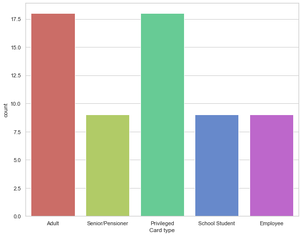

```python
sns.countplot(x='Card type', data=new_data3, palette='hls')
plt.show()
plt.savefig('count_plot')
sns.set(rc={'figure.figsize':(10,8)})
```

```python
#Selecting the top 6 data for each Card type
top1 = new_data3[new_data3['Card type'].isin(sort.index[:6])]
top1
```

|  | index | Location | Card type | Total Passengers |
| --- | --- | --- | --- | --- |
| 1 | 34 | T4 Eastern Suburbs and Illawarra Line | Adult | 2640848 |
| 2 | 22 | T3 Bankstown Line | Adult | 1129617 |
| 3 | 94 | Central Coast Newcastle Line | Adult | 605564 |
| 4 | 82 | Blue Mountains Line | Adult | 340721 |
| 5 | 118 | South Coast Line | Adult | 331184 |
| ... | ... | ... | ... | ... |
| 73 | 113 | Hunter Line | Privileged | 185 |
| 74 | 139 | Southern Highlands Line | Adult | 182 |
| 76 | 136 | Southern Highlands Line | Privileged | 130 |
| 78 | 53 | T5 Cumberland Line | Privileged | 75 |
| 81 | 77 | T7 Olympic Park Line | Privileged | 12 |

63 rows × 4 columns

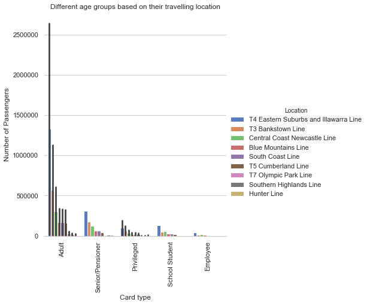

```python
# Load the dataset
# Draw a nested barplot to show relation between Card type and Total Passengers based on the location
sns.set(style="whitegrid")
g = sns.catplot(x="Card type", y="Total Passengers", hue="Location", data=top1,
                height=6, kind="bar", palette="muted")
g.despine(left=True)
g.set_ylabels("Number of Passengers")
plt.xticks(rotation = 90)
plt.title('Different age groups based on their travelling location')
```

## Results

From the overall implementation of results and plotting of data, we can conclude that Adult age group has travelled the most using the train where as T4 Eastern Suburbs and Illawarra Line is the most travelled location. Similarly, T3 Bankstown Line and Central Coast Newcastle Line are the second and third most used Location by Adults.

Similarly, an appropriate barplot has been visualized above that demonstrates and eases the understanding of the proper usage of train and the card type of users based on their location. Stating that we used March 20 as an evaluation date for the above datset, People who are employee seems to have travelled the least using train where as School Student as well as Privilege card holders that consists of Concessions and Free Travellers also did less of train travelling in comparison to that of Adult.

## Naive Bayes Classifiers to predict busiest and emptest route

### Using Multinomial NB

```python
display(TapOnoffDataMerge.head())
```

|  | mode | date | tap | time | loc | count | Parsed date | hours |
| --- | --- | --- | --- | --- | --- | --- | --- | --- |
| 0 | bus | 20161121 | off | 0:00 | 2000 | 82.0 | 2016-11-21 | 0 |
| 1 | bus | 20161121 | off | 0:00 | 2022 | 19.0 | 2016-11-21 | 0 |
| 2 | bus | 20161121 | off | 0:00 | 2026 | 28.0 | 2016-11-21 | 0 |
| 3 | bus | 20161121 | off | 0:00 | 2050 | 27.0 | 2016-11-21 | 0 |
| 4 | bus | 20161121 | off | 0:15 | 2000 | 62.0 | 2016-11-21 | 0 |

### Checking missing values

```python
pd.isnull(TapOnoffDataMerge).any()
TapOnoffDataMerge1 = TapOnoffDataMerge[TapOnoffDataMerge['mode'] == 'train']
TapOnoffDataMerge1
print(TapOnoffDataMerge1.info())
```

```
<class 'pandas.core.frame.DataFrame'>
Int64Index: 385328 entries, 123723 to 213219
Data columns (total 8 columns):
 #   Column       Non-Null Count   Dtype
---  ------       --------------   -----
 0   mode         385328 non-null  object
 1   date         385328 non-null  int64
 2   tap          385328 non-null  object
 3   time         385328 non-null  object
 4   loc          385328 non-null  object
 5   count        385328 non-null  float64
 6   Parsed date  385328 non-null  datetime64[ns]
 7   hours        385328 non-null  object
dtypes: datetime64[ns](1), float64(1), int64(1), object(5)
memory usage: 26.5+ MB
None
```

```python
TapOnoffDataMerge1.isnull().sum()
```

```
mode           0
date           0
tap            0
time           0
loc            0
count          0
Parsed date    0
hours          0
dtype: int64
```

```python
TapOnoffDataMerge2 = TapOnoffDataMerge1.groupby('loc')['count'].sum().to_frame()
TapOnoffDataMerge3 = TapOnoffDataMerge2.reset_index()
TapOnoffDataMerge3
```

|  | loc | count |
| --- | --- | --- |
| 0 | Albion Park Station | 2291.0 |
| 1 | Allawah Station | 96026.0 |
| 2 | Arncliffe Station | 78065.0 |
| 3 | Artarmon Station | 246202.0 |
| 4 | Ashfield Station | 530714.0 |
| ... | ... | ... |
| 266 | Wynyard Station | 2918578.0 |
| 267 | Wyong Station | 40746.0 |
| 268 | Yagoona Station | 41979.0 |
| 269 | Yennora Station | 18217.0 |
| 270 | Yerrinbool Station | 43.0 |

271 rows × 2 columns

```python
TapOnoffDataMerge3['Status'] = 'Unknown'
TapOnoffDataMerge3.loc[TapOnoffDataMerge3['count'].between(0, 100000, inclusive=False), 'Status'] = 'low'
TapOnoffDataMerge3.loc[TapOnoffDataMerge3['count'].between(100000, 400000, inclusive=True), 'Status'] = 'Moderate'
TapOnoffDataMerge3.loc[TapOnoffDataMerge3['count'].between(400000, 10000000, inclusive=True), 'Status'] = 'High'
```

#### Here, we have defined status field to know the volumn of total passangers.

1. Low (Population ranges between 0 to 100000)
2. Moderate (Population ranges between 100000 to 400000)
3. High (Populate ranges between 400000 to 10000000)

```python
AusPostalCodeNSWFinal1 = pd.merge(TapOnoffDataMerge3, TapOnoffDataMerge1, how='outer', left_on='loc', right_on='loc')
AusPostalCodeNSWFinal2 = AusPostalCodeNSWFinal1[['loc','Status','mode','Parsed date','tap','time','count_y']]
AusPostalCodeNSWFinal2.columns = ['loc','Status','mode','date','tap','time','Total Passenger']
```

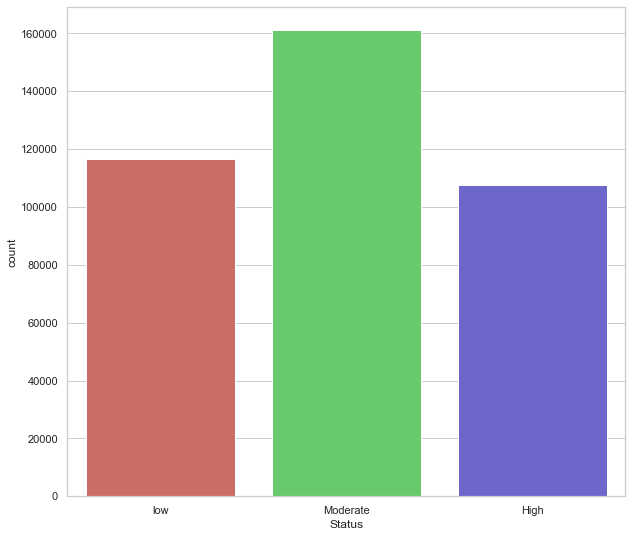

```python
sns.countplot(x= 'Status', data = AusPostalCodeNSWFinal2, palette = 'hls')
```

### Converting categorical variables to a dummy indicators

```python
Status = pd.DataFrame(AusPostalCodeNSWFinal2['Status'])
location = pd.DataFrame(AusPostalCodeNSWFinal2['loc']+' '+ AusPostalCodeNSWFinal2['Total Passenger'].astype(str))
location.head()
```

|  | 0 |
| --- | --- |
| 0 | Albion Park Station 19.0 |
| 1 | Albion Park Station 20.0 |
| 2 | Albion Park Station 21.0 |
| 3 | Albion Park Station 26.0 |
| 4 | Albion Park Station 18.0 |

```python
# Using LabelEncoder to fit and transform the data
from sklearn.preprocessing import LabelEncoder

feat = ['Status']
for x in feat:
    le = LabelEncoder()
    le.fit(list(Status[x].values))
    Status[x] = le.transform(list(Status[x]))
```

```python
Status['Status'].unique()
```

```
array([2, 1, 0], dtype=int64)
```

```python
from sklearn.feature_extraction.text import TfidfVectorizer
```

```python
#Using TFIDF for word count
vectorizer = TfidfVectorizer(min_df=2, max_features=70000, strip_accents='unicode',lowercase =True,
                            analyzer='word', token_pattern=r'\w+', use_idf=True,
                            smooth_idf=True, sublinear_tf=True, stop_words = 'english')
vectors = vectorizer.fit_transform(location[0])
vectors.shape
```

```
(385328, 2283)
```

```python
#Spliting test and train data
X_train, X_test, y_train, y_test = train_test_split(vectors, Status['Status'], test_size=0.2,random_state=200)
```

```python
print (X_train.shape)
print (y_train.shape)
print (X_test.shape)
print (y_test.shape)
```

```
(308262, 2283)
(308262,)
(77066, 2283)
(77066,)
```

```python
from sklearn.naive_bayes import MultinomialNB
from sklearn import metrics
from sklearn.model_selection import StratifiedKFold, cross_val_score, train_test_split
from sklearn.metrics import accuracy_score, confusion_matrix
clf = MultinomialNB()
clf.fit(X_train, y_train)
pred = clf.predict(X_test)
y_pred_train = clf.predict(X_train)
accuracy = metrics.accuracy_score(y_test, pred)
accuracy_train = metrics.accuracy_score(y_train, y_pred_train)

print('Accuracy in test data: %.4f\n' % accuracy)
print('Accuracy in train data: %.4f\n' % accuracy_train)
```

```
Accuracy in test data: 0.9978

Accuracy in train data: 0.9979
```

```python
matrix = confusion_matrix(y_test, pred)
print("Confusion Matrix on Test data is:- \n",matrix)

matrix = confusion_matrix(y_train, y_pred_train)
print("\n Confusion Matrix on Train data is:- \n",matrix)
```

```
Confusion Matrix on Test data is:-
 [[21556     0    61]
 [    0 32092    16]
 [   95     0 23246]]

 Confusion Matrix on Train data is:-
 [[ 85651      0    241]
 [     0 128905     63]
 [   328      0  93074]]
```

### Testing the Prediction

```python
AusPostalCodeNSWFinal3 = AusPostalCodeNSWFinal2[AusPostalCodeNSWFinal2['loc'] == 'Town Hall Station']
AusPostalCodeNSWFinal3
```

|  | loc | Status | mode | date | tap | time | Total Passenger |
| --- | --- | --- | --- | --- | --- | --- | --- |
| 338565 | Town Hall Station | High | train | 2016-11-21 | off | 0:00 | 54.0 |
| 338566 | Town Hall Station | High | train | 2016-11-21 | off | 0:15 | 50.0 |
| 338567 | Town Hall Station | High | train | 2016-11-21 | off | 0:30 | 19.0 |
| 338568 | Town Hall Station | High | train | 2016-11-21 | off | 4:45 | 19.0 |
| 338569 | Town Hall Station | High | train | 2016-11-21 | off | 5:00 | 80.0 |
| ... | ... | ... | ... | ... | ... | ... | ... |
| 343032 | Town Hall Station | High | train | 2016-08-13 | off | 16:45 | 1293.0 |
| 343033 | Town Hall Station | High | train | 2016-08-13 | off | 11:15 | 1300.0 |
| 343034 | Town Hall Station | High | train | 2016-08-13 | off | 9:15 | 939.0 |
| 343035 | Town Hall Station | High | train | 2016-08-13 | off | 22:15 | 577.0 |
| 343036 | Town Hall Station | High | train | 2016-08-13 | off | 21:45 | 547.0 |

4472 rows × 7 columns

```python
text = ['Town Hall Station']
text[0] = text[0].lower()
s = (vectorizer.transform(text))
print(s.shape)
d = (clf.predict(s))
```

```
(1, 2283)
```

```python
le.inverse_transform(d)[0]
```

```
'High'
```

### Results

Now, lets predict status of a location based on the location name. Here, for location 'Town Hall Station', we predicted the model to show 'High', which means this is the busiest station.